# What Makes TikTok Videos Engaging?

Linxuan Yang

2026-05-13

## What is this data about?

This visual data story explores what makes TikTok videos feel engaging during everyday viewing. The data was collected through observational logging, where each row records one TikTok video I watched. For each video, I recorded the video type, whether it was an advertisement, whether I watched the full video, the time of day, and an engagement score from 1 to 10. The main purpose of this story is to understand how different features of TikTok videos shaped my attention. Instead of asking other people for opinions, this data is based on repeated observations of my own viewing behaviour. This makes the story useful for noticing patterns in how content type, advertisement status, viewing time, and completion behaviour relate to engagement.

## Does time of day affect whether I finish videos?

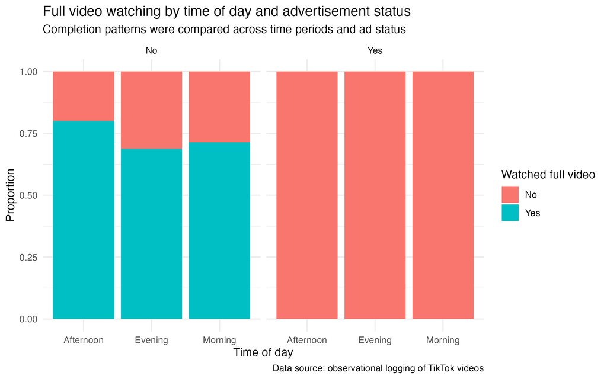

A proportional bar chart showing whether videos were watched fully across morning, afternoon, and evening, separated by advertisement status. Non-advertisement videos were more likely to be watched fully, while advertisement videos were not watched fully in the logged observations.

This chart looks at whether videos were watched fully during the morning, afternoon, or evening. It also separates videos by advertisement status, which helps show whether ads changed my viewing behaviour. The chart suggests that non-advertisement videos were more likely to be watched fully, while advertisement videos were easier to skip.

## How did engagement change by time of day?

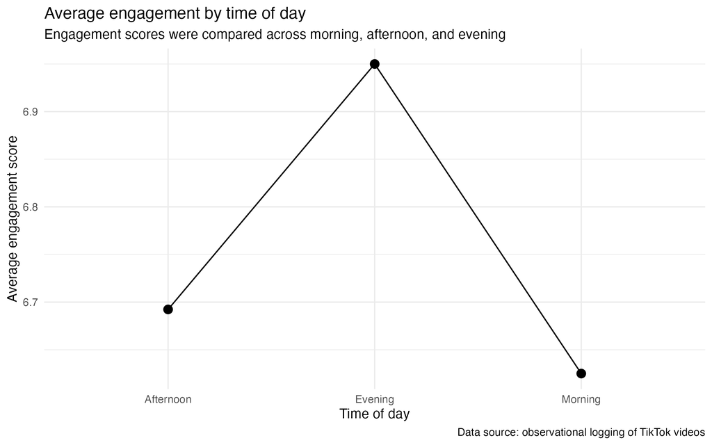

A line chart showing average engagement scores across morning, afternoon, and evening. Evening videos had the highest average engagement score, while morning videos had the lowest.

This chart compares average engagement scores across different times of day. Evening videos had the highest average engagement score, while morning videos had the lowest. This suggests that my engagement with TikTok videos may have changed depending on my daily routine and when I had more time to watch videos.

## Completion changed with time and advertisement status

The third chart looks at whether videos were watched fully across different times of day, while also separating advertisement and non-advertisement videos. This makes the comparison stronger because it uses three variables: time of day, advertisement status, and whether the video was watched fully. The chart shows that advertisement videos were not watched fully in the logged observations. In contrast, non-advertisement videos were more likely to be completed, especially during the afternoon and morning. This suggests that advertisement status had a strong effect on completion behaviour. Even when the time of day changed, advertisements were still less likely to hold attention until the end.

## Evening viewing was the most engaging

The final chart compares average engagement scores across different times of day. The pattern shows that evening videos had the highest average engagement score, while morning videos had the lowest. Afternoon engagement was between the two. This suggests that my TikTok viewing behaviour may be affected by daily routine. In the evening, I may have had more time and attention to watch videos for entertainment, which could explain the higher engagement score. In the morning, I may have been less focused on watching videos fully or rating them highly.

## What the story shows

[figure not shown]

## Wait, another dancing cat?

[figure not shown]

A tabby cat dancing

## A dance team of kittens!

[figure not shown]

Five kittens head banging